# cschmidt-quant_assignment2

cschmidt

9/15/2020

1. Load csv document from assignment 1. Filter out negative values.

```r
library(dplyr)
df<-read.csv("assignment1.csv")
df2<-filter(df, weeklyhoursworked >= 0, salary >= 0, children >= 0, totalmarriages >= 0)
```

2. Means of Continuous Variables

```r
mwkw<-mean(df2$weeklyhoursworked)
ms<-mean(df2$salary)
mtm<-mean(df2$totalmarriages)
mwkw
```

```
## [1] 23.7742
```

```r
ms
```

```
## [1] 28023.11
```

```r
mtm
```

```
## [1] 0.9989581
```

The mean weekly hours in Nevada worked is 23.77 hours. The mean salary in Nevada is $28,023.11. The mean number of total marriages for Nevada residents is 1.

3. Sample Standard Deviations of Continuous Variables

```r
sdmwkw<-sd(df2$weeklyhoursworked)
sds<-sd(df2$salary)
sdtm<-sd(df2$totalmarriages)
sdmwkw
```

```
## [1] 20.93249
```

```r
sds
```

```
## [1] 50521.49
```

```r
sdtm
```

```
## [1] 0.8464453
```

The standard deviation of weekly hours in Nevada worked is 20.93 hours. The standard deviation of salary in Nevada is $50,521.49. The standard deviation of total marriages for Nevada residents is 0.85.

4. Interquartile Range of Continuous Variable

```r
IQR(df2$weeklyhoursworked)
```

```
## [1] 40
```

```r
IQR(df2$salary)
```

```
## [1] 40000
```

```r
IQR(df2$totalmarriages)
```

```
## [1] 1
```

5. 95% Confidence Intervals (presuming normal distributions?)

```r
mwkw+(1.96*(sdmwkw/sqrt(23995)))
```

```
## [1] 24.03906
```

```r
mwkw-(1.96*(sdmwkw/sqrt(23995)))
```

```
## [1] 23.50934
```

```r
ms+(1.96*(sds/sqrt(23995)))
```

```
## [1] 28662.36
```

```r
ms-(1.96*(sds/sqrt(23995)))
```

```
## [1] 27383.86
```

```r
mtm+(1.96*(sdtm/sqrt(23995)))
```

```
## [1] 1.009668
```

```r
mtm-(1.96*(sdtm/sqrt(23995)))
```

```
## [1] 0.988248
```

The 95% confidence interval of weekly work hours in Nevada is from 23.51 hours to 24.04 hours. The 95% confidence interval for salary in Nevada is from $27,383.86 to $28,662.36. The 95% confidence interval for total marriages is from 0.99 marriages to 1.01 marriages.

6. Histograms

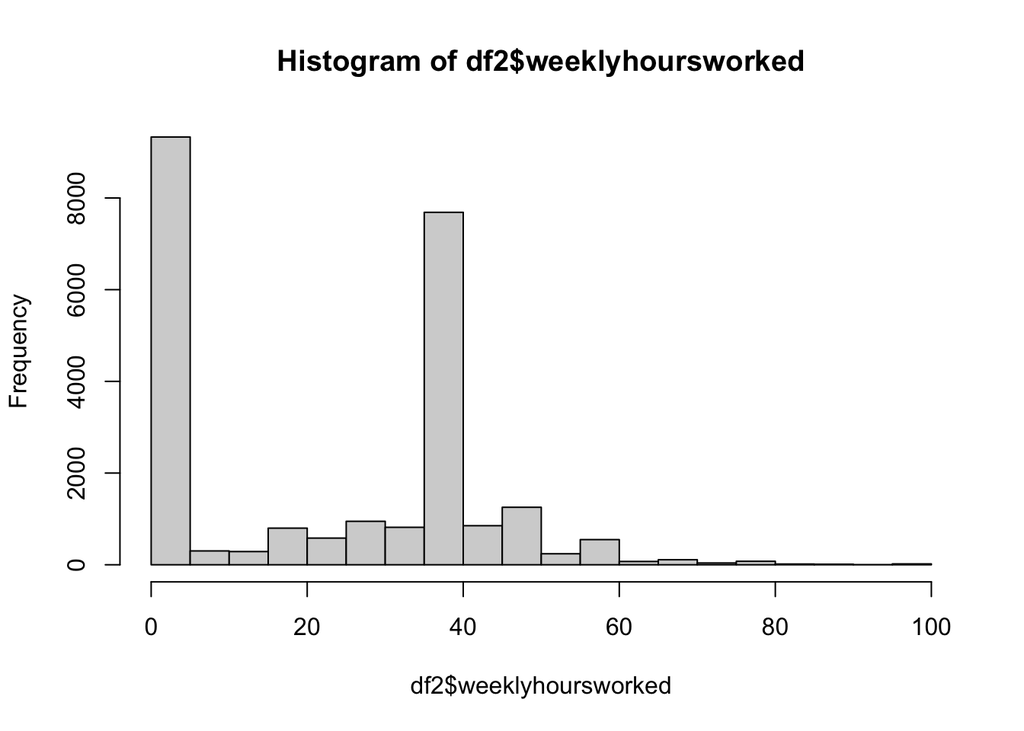

```r
hist(df2$weeklyhoursworked)
```

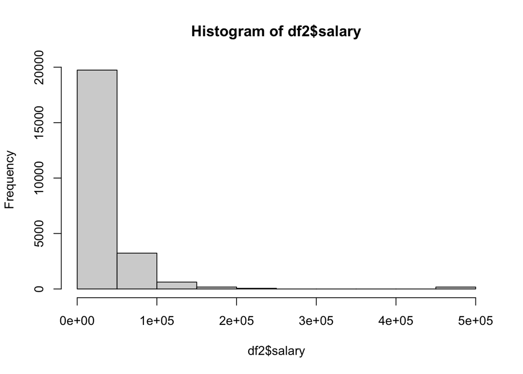

```r
hist(df2$salary)
```

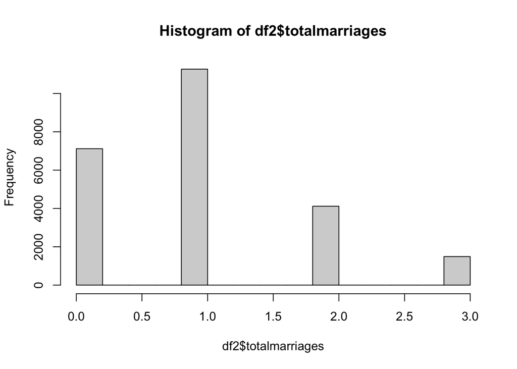

```r
hist(df2$totalmarriages)
```

For weekly hours worked, there are clear spikes at the 40 hour work week and the zero hour work week. This makes sense. The general layout of the rest of the histogram shows a slow ramp up to the mean and a slow ramp down after it.

7. 95% Confidence Intervals for the Proportion of Population in Each Category of Categorical Variables.

There are two categorical variables — marital status and amount of children had over the past year.

```r
unique(df2$maritalstatus)
```

```
## [1] "Divorced"                            "Never married or under 15 years old"
## [3] "Separated"                           "Widowed"
## [5] "Married"
```

```r
unique(df2$children)
```

```
## [1] 0 2 1
```

```r
t.test(df2$maritalstatus == "Divorced")
```

```
##
##  One Sample t-test
##
## data:  df2$maritalstatus == "Divorced"
## t = 63.056, df = 23994, p-value < 2.2e-16
## alternative hypothesis: true mean is not equal to 0
## 95 percent confidence interval:
##  0.1377358 0.1465734
## sample estimates:
## mean of x
## 0.1421546
```

```r
t.test(df2$maritalstatus == "Never married or under 15 years old")
```

```
##
##  One Sample t-test
##
## data:  df2$maritalstatus == "Never married or under 15 years old"
## t = 100.61, df = 23994, p-value < 2.2e-16
## alternative hypothesis: true mean is not equal to 0
## 95 percent confidence interval:
##  0.2909066 0.3024670
## sample estimates:
## mean of x
## 0.2966868
```

```r
t.test(df2$maritalstatus == "Widowed")
```

```
##
##  One Sample t-test
##
## data:  df2$maritalstatus == "Widowed"
## t = 38.426, df = 23994, p-value < 2.2e-16
## alternative hypothesis: true mean is not equal to 0
## 95 percent confidence interval:
##  0.05501339 0.06092743
## sample estimates:
##  mean of x
## 0.05797041
```

```r
t.test(df2$maritalstatus == "Married")
```

```
##
##  One Sample t-test
##
## data:  df2$maritalstatus == "Married"
## t = 150.85, df = 23994, p-value < 2.2e-16
## alternative hypothesis: true mean is not equal to 0
## 95 percent confidence interval:
##  0.4804434 0.4930927
## sample estimates:
## mean of x
## 0.4867681
```

```r
t.test(df2$maritalstatus == "Separated")
```

```
##
##  One Sample t-test
##
## data:  df2$maritalstatus == "Separated"
## t = 20.014, df = 23994, p-value < 2.2e-16
## alternative hypothesis: true mean is not equal to 0
## 95 percent confidence interval:
##  0.01481199 0.01802818
## sample estimates:
##  mean of x
## 0.01642009
```

The true amount of divorced people in Nevada is 95% likely to be between 13.77% and 14.66% of the population.

The true amount of never married or under 15 years old people in Nevada is 95% likely to be between 29.09% and 30.25% of the population.

The true amount of widowed people in Nevada is 95% likely to be between 5.5% and 6.09% of the population.

The true amount of married people in Nevada is 95% likely to be between 48.04% and 49.31% of the population.

The true amount of separated people in Nevada is 95% likely to be between 1.48% and 1.80% of the population.

```r
t.test(df2$children == 0)
```

```
##
##  One Sample t-test
##
## data:  df2$children == 0
## t = 260.41, df = 23994, p-value < 2.2e-16
## alternative hypothesis: true mean is not equal to 0
## 95 percent confidence interval:
##  0.7330942 0.7442135
## sample estimates:
## mean of x
## 0.7386539
```

```r
t.test(df2$children == 1)
```

```
##
##  One Sample t-test
##
## data:  df2$children == 1
## t = 17.894, df = 23994, p-value < 2.2e-16
## alternative hypothesis: true mean is not equal to 0
## 95 percent confidence interval:
##  0.01172689 0.01461193
## sample estimates:
##  mean of x
## 0.01316941
```

```r
t.test(df2$children == 2)
```

```
##
##  One Sample t-test
##
## data:  df2$children == 2
## t = 88.997, df = 23994, p-value < 2.2e-16
## alternative hypothesis: true mean is not equal to 0
## 95 percent confidence interval:
##  0.2427109 0.2536425
## sample estimates:
## mean of x
## 0.2481767
```

It is 95% likely that the amount of people who had 0 children in the past 12 months in Nevada is between 73.31% and 74.42% of the population.

It is 95% likely that the amount of people who had 1 child in the past 12 months in Nevada is between 1.17% and 1.46% of the population.

It is 95% likely that the amount of people who had 2 children in the past 12 months in Nevada is between 24.27% and 25.36% of the population??